# State of the `weavingspace` code

Incuding a glossary of tiling terms

Author

David O’Sullivan

Published

February 4, 2024

**NoteUpdate History**

| Date | Changes |
| --- | --- |
| 2026-04-17 | Corrected images and other links. |
| 2025-02-08 | Updated and converted to `.qmd`. |
| 2024-02-04 | Initial draft. |

# The state of the tiling universe

Setting aside the small matter of [the discovery in 2023 of an aperiodic monotile](https://arxiv.org/abs/2305.17743), here are some notes (in lieu of a long slack post) on where the *weavingspace* project is at. Most links in the below are to items in the glossary.

# Notes on the code

**8 February 2025**

The latest round of coding has added a lot, particularly with respect to correctly implementing the labelling of distinct transitivity classes of tiling vertices, tiling edges, and tiles themselves.

In our case translations are baked in—we know these exist, because we put them there. Finding rotation and reflection symmetries which preserve the tiling is necessary for detecting transitivity classes, which in turn is required to label edges and vertices in order to support principled modification of tiles so as to maintain tileability.

Getting to this point has revealed some weaknesses in the Rube Goldberg / Heath Robinson machinery along with other desiderata.

In no particular order:

## Modifying tiles

The whole point of venturing into topology was to enable principled modification of tiles—typically making them more ‘elaborate’ in an Escher-like way. For example, [this tiling](https://github.com/DOSull/weaving-space/blob/main/examples/example-tiles-wobbly-escherian.ipynb) is derived (by hand) by putting a sinusoidal curve along each edge of square tiling, and indicates the surprising variety in tilings that might be enabled by allowing this possibility.

At the moment the `Topology` class enables a number of transformations of tiling vertices and edges:

- [‘Zig-zag’ an edge](https://dosull.github.io/weavingspace/doc/weavingspace/topology.html#Topology.zigzag_edge), which will add corners along an edge in a zig-zag pattern.
- [Rotate an edge](https://dosull.github.io/weavingspace/doc/weavingspace/topology.html#Topology.rotate_edge) about its centre, which may cause its associated end point vertices to move.
- [‘Push’ a vertex](https://dosull.github.io/weavingspace/doc/weavingspace/topology.html#Topology.push_vertex) will move a vertex in the direction of the resultant unit vector of its incoming incident edges.
- [Nudge a vertex](https://dosull.github.io/weavingspace/doc/weavingspace/topology.html#Topology.nudge_vertex) will move all vertices in a specifed transitivity class by a given displacement. This almost always makes tiles non-similar.

Some examples of these can be seen in [this notebook](https://github.com/DOSull/weavingspace/blob/main/examples/topology-working.ipynb), although a less impenetrable interface to applying transformations is likely required.

It’s also worth noting that the `Topology` class offers a likely more reliable way to generate dual tilings, than the [`tiling_utils.get_dual_tile_unit_`](https://dosull.github.io/weavingspace/doc/weavingspace/tiling_utils.html#get_dual_tile_unit) function.

## Corners and vertices

The tile corner / tiling vertex distinction is not carefully observed in the code. The transitivity class implementation should make this easier to do. For example it should be easy enough now to *not* label corners, as the logic of tiling symmetry implies.

## The `symmetry` code

The symmetry now works, and can accurately detect the [symmetries of a tile](https://github.com/DOSull/weavingspace/blob/main/examples/symmetry-working.ipynb), and of a [tiling](https://github.com/DOSull/weavingspace/blob/main/examples/topology-working.ipynb).

As seen in the [topology notebook](https://github.com/DOSull/weavingspace/blob/main/examples/topology-working.ipynb) we can now detect and display all the symmetries of a tiling (probably reliably).

## Graphs and `networkx`

Late in the process of implementing transitivity classes, I (with some reluctance) imported `networkx` to resolve a gnarly problem of extracting the ‘exclusive supersets’ of a list of sets. And of course… 5 lines of graph code specifically the [`connected_components`](https://networkx.org/documentation/stable/reference/algorithms/generated/networkx.algorithms.components.connected_components.html#networkx.algorithms.components.connected_components) method and the problem disappeared.

## Integration

At the moment, the `Topology` code is almost entirely independent of the main codebase. A `Topology` object is constructed by supplying a `Tileable` instance, and the code makes extensive use of functions in the `tiling_utils` module, but no more than that. Whether a `Topology` should be embedded in a `Tileable` by default, or whether one should be used to generate dual tilings or not is an open question [the [dual generation code in `Topology`](https://dosull.github.io/weaving-space/doc/weavingspace/topology.html#Topology.generate_dual) is much more satisfying and (probably) robust than the [`tiling_utils` implementation](https://dosull.github.io/weaving-space/doc/weavingspace/tiling_utils.html#get_dual_tile_unit)].

## The superfluity of tiles in `WeaveUnit` tilings

Because of how they are generated our weave based `Tileable` objects (`WeaveUnit`s) often contain more tiles than strictly required. In many biaxial tilings there are two times the required number. In the triaxial case it is often much worse than that with as many as 9 times more tiles than required. This causes issues for the `Topology` code. Also to consider here is whether weave units with `spacing < 1.0` should even be allowed to have a topology!

# Glossary

An attempt to define terms and how they relate to aspects of the code.

## Mathematical tiling terms

### Corner

A point on the perimeter of a tile polygon where the perimeter changes direction. A polygon corner in the usual sense. Distinct from a tiling vertex. Corners are properties of individual tiles, not of the tiling.

### Dual tiling

The tiling formed from an existing tiling by placing a vertex in each tile and joining them by edges between any two tiles that share an edge in the original tiling. Tiles become vertices and vertices become tiles. The relation is reciprocal and essentially topological not geometric, since the placement of a vertex in a tile is ill-defined. An important dual relation is that between the [Archimedean](https://en.wikipedia.org/wiki/Euclidean_tilings_by_convex_regular_polygons#Archimedean,_uniform_or_semiregular_tilings) and the [Laves](https://en.wikipedia.org/wiki/List_of_Euclidean_uniform_tilings#Laves_tilings) tilings.

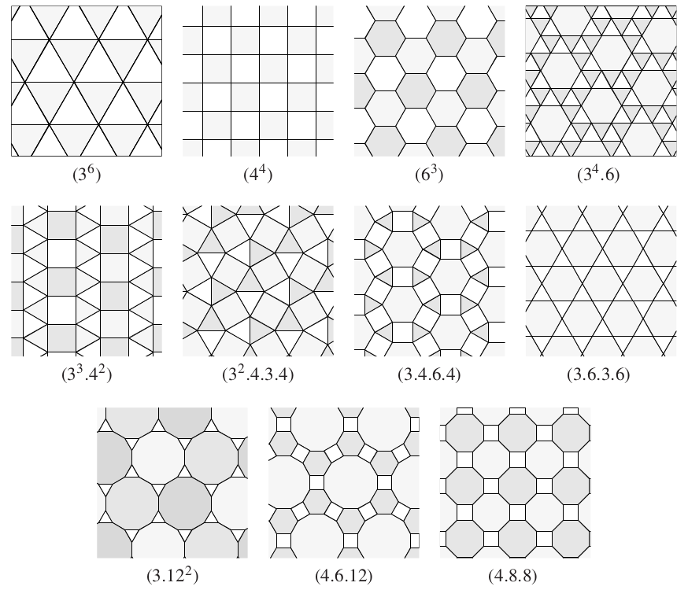

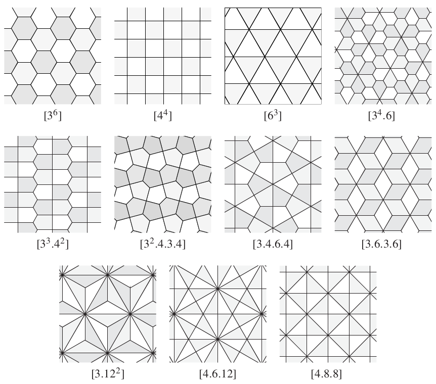

### Edge

The line along which two tiles in a tiling meet. An edge has a vertex at each end and any number of corners along its length. Edges are a property of a tiling, not of individual tiles.

### Element

Collective term for tiles, edges and vertices.

### Fundamental unit

A subset of a tiling which under two non-parallel translations can tile the plane. It is important to realise that the fundamental unit of a tiling is not uniquely defined. In a tiling with two translation vectors, for example, any parallelogram shaped region defined by those two vectors is a fundamental unit. In our implementation approximately equivalent to a `Tileable`.

### Periodic tiling

A tiling with two non-parallel translations among its symmetries.

### Prototile

Any one of the tiles that constitute a tiling. A set of prototiles is said to ‘admit’ a tiling. In our implementation the term is applied to the geometric union of the polygons in a `Tileable`, which is closer to the fundamental unit. Refactoring to make things map better onto the literature is an option…

### Reflection

The image of a geometric object under a reflection transformation is its mirror image. A possible symmetry of a tile or tiling. Defined by a line of symmetry in which the reflection occurs.

### Rotation

A transformation of the plane around a fixed point (the centre of rotation) by a given angle. One of the possible symmetries of a tile or tiling.

### Side

A side of a polygon as commonly understood, connecting two of its corners. Distinct from a tiling edge. There is always a change in direction at a corner, but there may be many corners along a tiling edge. Tile corners and tiling vertices are often coincident but a vertex is not always a corner (there might be no change in direction) and corner is not always a vertex (if it is along an edge, when it will be incident on only two tiles).

### Symmetry

OMG. All of mathematics. But seriously… albeit briefly, in our context a symmetry is any transformation of a tiling that maps its elements back on to other matching elements. Tiles also have symmetries but the symmetries of a tiling and of its constituent tiles are not the same. For example in the Cairo tiling (Laves 3.3.4.3.4 in the figure above), the pentagonal tiles have only a single reflection symmetry (also a symmetry of the tiling), but the tiling also has 90° rotational symmetries.

### Tile

A polygon that when arranged in a tiling exhausts the plane. A polygon is formed by straight sides connecting corners.

### Tiling

A covering of the plane with tiles. According to Grünbaum and Shephard 1987, page 16: > “… a countable family of closed sets $\mathcal{T}=\{T_1,T_2,\ldots\}$ which covers the plane without gaps or overlaps. More explicitly, the union of the sets $T_1,T_2,\ldots$ (which are known as the *tiles* of $\mathcal{T}$) is to be the whole plane, and the interiors of the sets $T_i$ are to be pairwise disjoint”

So… a close cousin to a GIS coverage then…

### Transformation

A one-to-one mapping of every point in the plane to another point in the plane.

### Transitivity class

A group of elements (tiles, vertices, or edges) that map onto one another under the symmetries of the tiling. This concept is a subtle one. The tiling below has *two* transitivity classes of tile, since there is no transformation that maps central tiles on to outer tiles while also mapping all tiles onto a tile. Those central tiles only ever map onto other central tiles, hence they are in a different transitivity class than the outer tiles, which form a second transitivity class. A tiling with one transitivity class is termed *isohedral*, while the terms 2-hedral, *n*-hedral etc. are also used. Similar notions apply to vertices and edges, where the terms are respectively *isogonality* and *isotoxality*. The isohedral tilings of the plane have been thoroughly explored (for example it is proven that there are 81 types…).

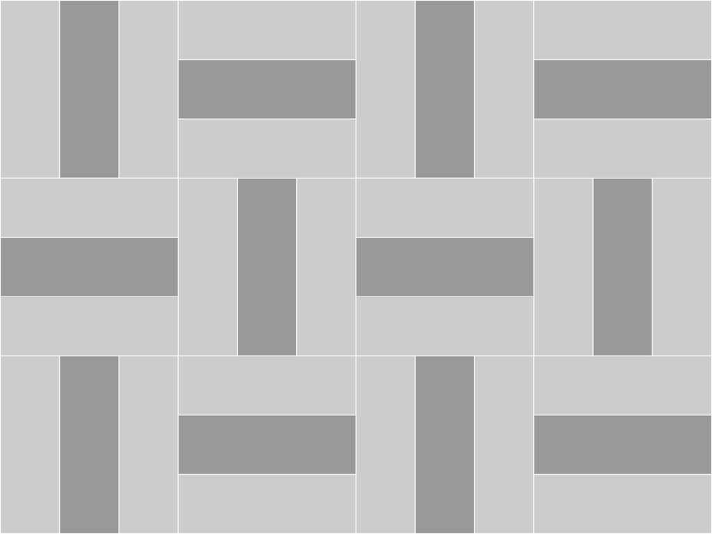

the ‘cheese sandwich’ 2-hedral tiling

### Translation

A transformation in which every point in the plane is displaced by a defined vector, i.e. $(x,y)\rarr(x+\delta x,y+\delta y)$. In our case all tilings are periodic, meaning that they have two non-parallel transformation symmetries.

### Vertex

Points in a tiling at which three or more tiles meet, which are therefore the end points of tiling edges. Often but not always coincident with the corners of tiles. In particular tiling vertices may result from the tiling. For example in the ‘cheese sandwich’ tiling above, the tiling induces two vertices along the long sides of each rectangle.

## Implementation terms

Not all the mathematical terminology of tiling is accurately mirrored in the code. Some liberties have been taken given that the implementation is not directly modelled on mathematical theory.

### Labelling

A general term for the process of assigning tiles, vertices and edges to transitivity classes, which allows them to be labelled. Currently tiles don’t get labelled, but since they are in transitivity classes it wouldn’t be hard to do this.

### `prototile`

A simple polygon associated with a `Tileable` object derived from either a rectangle or a hexagon.

### Regularised prototile

This really only matters for weave based tilings where generation of the `Tileable` object produces ‘fragments’ that are parts of the tiles that lie outside the simple prototile rectangle of hexagon shape. Some nasty code attempts to assemble such fragment back into a more manageable set and the result jigaw puzzle shaped piece is the regularised prototile. Here’s an example (the red outline below):

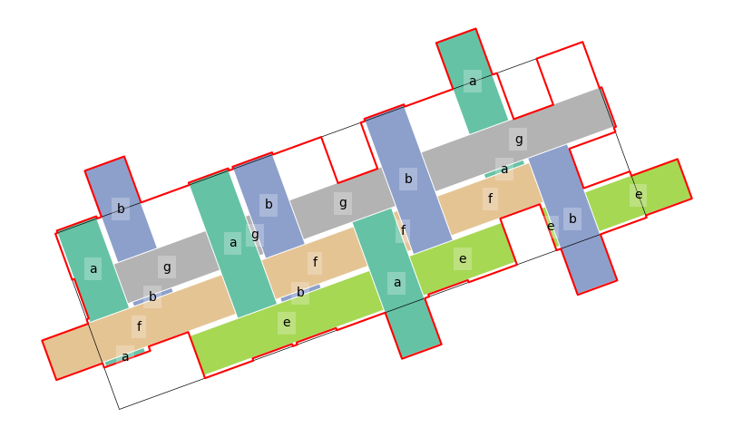

### ‘Shape group’

Identifying the different shapes in a tiling is a key step in finding transitivity classes. There is still a `shape_groups` attribute of the `Topology` class as a result. More work on the symmetry code will probably make these assignments more reliable.

### Tileable

The central object class in the code base. A `Tileable` instance has the following attributes that more or less loosely link to the mathematical concepts above:

- `tiles` a [`geopandas.GeoDataFrame`](https://geopandas.org/en/stable/docs/reference/api/geopandas.GeoDataFrame.html) of [`shapely.geometry.Polygon`](https://shapely.readthedocs.io/en/stable/reference/shapely.Polygon.html) objects, with associated `tile_id` (by default a single character string) identifying tiles that can be associated with different data attributes.
- `prototile` also a `GeoDataFrame`, containing a single polygon shape which will be a rectangle or hexagon or simple modification (by stretching or skewing) of those, which indicates how the tiling can be constructed. Vectors joining opposite faces of the prototile form the `vectors` of the `Tileable` and model the translation symmetries of the tiling.
- `regularised_prototile` also a `GeoDataFrame` containing a single polygon. It is possible for the `prototile` to cut across tile polygons in the `Tileable`; the regularised prototile is a different tileable polygon containing only complete tiles.
- `vectors` a set of tuples of x and y displacements by which the polygons in the `Tileable`‘s `tiles` attribute are ’copied and pasted’ across a map area. These are not a minimal set of translation vectors. For example, hexagonally based tilings have 6 vectors (3 each in two different directions) where a strict mathematical representation would require only 2 (the third is the difference between the other two).

### Tile unit

A specialisation of the `Tileable` class that represents ‘traditional’ geometric tilings, constructed by geometry as implemented in the [`tiling_geometries` module](https://dosull.github.io/weaving-space/doc/weavingspace/tiling_geometries.html).

### Topology

A class that attempts to represent the elements in a tiling (i.e. tiles, vertices and edges) and the relations among them, in particular enabling labelling by detecting the transitivity classes of the tiling. Determinining these classes makes deforming tiles while preserving tileability possible.

### Translation vector

An $(x, y)$ tuple displacement by which repetitions of the `Tileable.tiles` polygons are combined to yield a tiling.

### Weave unit

A specialisation of the `Tileable` class that represents tilings that can be produced by weaving. A particular feature of note is the `aspect` attribute which defines the width of ‘strands’ in the weave relative to their spacing, and may mean that the resulting tiling has ‘holes’ (and are hence not tilings as defined by Grünbaum & Shephard). Note that there is theory of *isonemal* tilings which are precisely tilings that can be generated by weaving albeit without gaps (which in our implementation equates to `aspect = 1`).